# Cell-type deconvolution of bulk RNA-seq: PredictFiberType

Session 4 — practical tutorial

Nikolay Oskolkov

2026-10-26

# 1 Overview

Bulk RNA-seq measures pooled expression from many cells. When cell types have distinct transcriptional signatures, the bulk profile can be modelled as a mixture of reference profiles. This tutorial runs **PredictFiberType** to estimate the proportion of type I (slow-twitch) skeletal-muscle fibres from bulk RNA-seq and compares predictions with reference proportions supplied in the repository.

The method uses a signature matrix derived from skeletal-muscle single-nucleus RNA-seq and **DeconRNASeq** R package. It estimates non-negative mixture proportions; it is a reference-based statistical deconvolution method rather than a conventional classification model.

- PredictFiberType: https://github.com/OlaHanssonLab/PredictFiberType
- Oskolkov et al. (2022): https://doi.org/10.1186/s13395-022-00299-4
- Gong & Szustakowski (2013): https://doi.org/10.1093/bioinformatics/btt090

# 2 Set up the environment

The following chunk clones the repository if needed. Git and internet access are required.

```r
repo_url <- "https://github.com/OlaHanssonLab/PredictFiberType.git"

repo_dir <- "PredictFiberType"

if (!dir.exists(repo_dir)) {
  status <- system2("git", c("clone", "--depth", "1", repo_url, repo_dir))
  if (!identical(status, 0L)) stop("Git clone failed. Check internet access and Git installation.")
}

setwd("PredictFiberType")
knitr::opts_knit$set(root.dir = getwd())
```

Install the required Bioconductor package if necessary.

```r
if (!requireNamespace("BiocManager", quietly = TRUE))
  install.packages("BiocManager", repos = "https://cloud.r-project.org")
if (!requireNamespace("DeconRNASeq", quietly = TRUE))
  BiocManager::install("DeconRNASeq", ask = FALSE, update = FALSE)

library("DeconRNASeq")
```

# 3 Inspect input data

The script `PredictFiberType.R` in the cloned repo expects a normalized and batch-corrected expression matrix with genes in rows, samples in columns, and gene symbols as row names. The optional truth file contains measured type I fibre fractions for matching samples. Below we are going to inspect that all the necessary files (such as the signature matrix) are present and proceed with reading the bulk gene expression matrix.

```r
required_files <- c("PredictFiberType.R", "bulk_expr.txt", "true_type1.txt", "signatures_matrix.txt")

missing_files <- required_files[!file.exists(required_files)]

if (length(missing_files)) stop("Missing repository file(s): ", paste(missing_files, collapse = ", "))

file.info(required_files)[, c("size", "isdir")]
```

```
##                          size isdir
## PredictFiberType.R       2689 FALSE
## bulk_expr.txt         2083769 FALSE
## true_type1.txt            354 FALSE
## signatures_matrix.txt     771 FALSE
```

```r
bulk <- read.delim("bulk_expr.txt", check.names = FALSE, row.names = 1)
dim(bulk)
```

```
## [1] 26654    22
```

```r
bulk[seq_len(min(5,nrow(bulk))), seq_len(min(5,ncol(bulk))), drop = FALSE]
```

```
##            2019001 2015036 2015032 2016047 2015023
## PPP1R12BP1       3       3       1       1       0
## AC024067.1       7       8       7       4       4
## TTTY10        1361    1208    1464    1456    1717
## KDM5D         1058     956    1071    1015    1041
## FAM224A          4       9       9       9       8
```

We can see that the rows represent the gene names and the columns represent the sample ids.

# 4 Run PredictFiberType

The repository README documents this command: `Rscript PredictFiberType.R bulk_expr.txt true_type1.txt`. The script writes `deconv_prediction.txt` and a comparison plot as outputs.

```r
run_log <- system2(file.path(R.home("bin"), "Rscript"),
                   args = c("PredictFiberType.R", "bulk_expr.txt", "true_type1.txt"),
                   stdout = TRUE, stderr = TRUE)

cat(paste(run_log, collapse = "\n"))
```

```
## [1] "READING MATRIX OF SIGNATURES"
##        fast_twitch_typeII slow_twitch_typeI
## EMC10          6.53917051         4.2730236
## TNNT3          3.18049155         0.5509372
## ATP2A1         2.43625192         0.2762836
## MYH2           2.53993856         0.2933985
## TPM1           1.46313364         0.2184189
## MYBPC2         0.99001536         0.0790546
## MYLPF          1.43087558         0.4058680
## TNNC2          2.49078341         1.1955990
## TPM3           0.26728111         2.2550937
## TNNT1          0.77803379         4.2184189
## MYH7B          0.07296467         1.0546047
## MYH7           0.48156682         2.0065200
## ATP2A2         0.31182796         3.4971475
## XPO4           0.26190476         3.1108394
## CD36           0.57450077         2.3748981
## TNNI1          0.31413210         1.3292584
## LGR5           0.09984639         0.8622657
## USP54          0.31566820         1.2567237
## [1] "READING BULK EXPRESSION MATRIX"
##            2019001 2015036 2015032 2016047 2015023
## PPP1R12BP1       3       3       1       1       0
## AC024067.1       7       8       7       4       4
## TTTY10        1361    1208    1464    1456    1717
## KDM5D         1058     956    1071    1015    1041
## FAM224A          4       9       9       9       8
## [1] 26654    22
## [1] "PERFORMING DECONVOLUTION ANALYSIS"
##
##
##
##
##
## svd calculated PCA
## Importance of component(s):
##                  PC1    PC2
## R2            0.9906 0.0093
## Cumulative R2 0.9906 0.9999
##
```

[output cut: 15 more lines]

```
## 2017059          0.5947832         0.4052168
## 2017062          0.7099919         0.2900081
## 2019002          0.6603800         0.3396200
## 2017060          0.5450221         0.4549779
## 2015025          0.6477362         0.3522638
## 2015033          0.7401105         0.2598895
## 2016049          0.4926147         0.5073853
## 2015040          0.7483415         0.2516585
## 2017058          0.5939418         0.4060582
## 2017065          0.6190628         0.3809372
## 2016044          0.4690502         0.5309498
## [1] "COMPARING TRUE VS. PREDICTED RESULTS"
## [1] "PLOTTING TRUE VS. PREDICTED RESULTS"
## null device
##           1
```

```r
if (!file.exists("deconv_prediction.txt"))
  stop("The script did not create deconv_prediction.txt; inspect the output above.")
```

# 5 Read prediction and truth files

The `PredictFiberType` method produced the `deconv_prediction.txt` table as an output. First, let us inspect the table structure. Repository / script versions can differ slightly in whether sample IDs are stored in a column or row names.

```r
pred_raw <- read.delim("deconv_prediction.txt", check.names = FALSE, stringsAsFactors = FALSE)
names(pred_raw); head(pred_raw)
```

```
## [1] "fast_twitch_typeII" "slow_twitch_typeI"
```

```
##         fast_twitch_typeII slow_twitch_typeI
## 2019001          0.7307211         0.2692789
## 2015036          0.7208636         0.2791364
## 2015032          0.6915982         0.3084018
## 2016047          0.5771765         0.4228235
## 2015023          0.7231487         0.2768513
## 2017068          0.7154878         0.2845122
```

```r
# Read the truth file without assuming it has a header: the repository describes it as
# a sample-indexed column, and the first field may therefore be a sample ID.
truth_raw <- read.table("true_type1.txt", header = FALSE, sep = "", check.names = FALSE,
                        stringsAsFactors = FALSE, fill = TRUE, comment.char = "")
names(truth_raw); head(truth_raw)
```

```
## [1] "V1" "V2"
```

```
##          V1                      V2
## 1 SAMPLE_ID TRUE_SLOW_TWITCH_TYPE_I
## 2   2015021                   0.315
## 3   2015023                   0.317
## 4   2015025                   0.405
## 5   2015026                   0.279
## 6   2015028                   0.272
```

The helper below tries to detect ID and fraction columns. If the printed column names reveal a different layout in a future repository revision, update the two column selections accordingly.

```r
# Predictions: identify sample ID and numeric type-I estimate.
pred <- as.data.frame(pred_raw, check.names = FALSE)
if (ncol(pred) < 2L) {
  pred <- data.frame(sample_id = rownames(pred), pred, check.names = FALSE)
} else {
  id_candidates <- which(grepl("sample|^id$|name", names(pred), ignore.case = TRUE))
  id_col <- if (length(id_candidates)) id_candidates[1] else 1L
  pred$sample_id <- as.character(pred[[id_col]])
}
num_pred <- which(vapply(pred, is.numeric, logical(1)))
num_pred <- setdiff(num_pred, which(names(pred) == "sample_id"))
if (!length(num_pred)) {
  for (nm in setdiff(names(pred), "sample_id"))
    suppressWarnings(pred[[nm]] <- as.numeric(as.character(pred[[nm]])))
  num_pred <- which(vapply(pred, is.numeric, logical(1)))
}
if (!length(num_pred)) stop("Could not identify a numeric prediction column.")
named_pred <- num_pred[grepl("type.?1|type.?i|slow|fraction|prop", names(pred)[num_pred], ignore.case = TRUE)]
pred_col <- if (length(named_pred)) named_pred[1] else num_pred[1]
pred_df <- data.frame(sample_id = rownames(pred),
                      predicted_type1 = as.numeric(pred[[2]]))

# Truth file: support a two-column ID/value file or a single-column fraction file.
truth <- as.data.frame(truth_raw, check.names = FALSE)
if (ncol(truth) >= 2L) {
  id_candidates <- which(grepl("sample|^id$|name", names(truth), ignore.case = TRUE))
  id_col <- if (length(id_candidates)) id_candidates[1] else 1L
  num_truth <- which(vapply(truth, is.numeric, logical(1)))
  num_truth <- setdiff(num_truth, id_col)
  if (!length(num_truth)) {
    for (nm in setdiff(names(truth), names(truth)[id_col]))
      suppressWarnings(truth[[nm]] <- as.numeric(as.character(truth[[nm]])))
    num_truth <- setdiff(which(vapply(truth, is.numeric, logical(1))), id_col)
  }
  if (!length(num_truth)) stop("Could not identify the measured type-I fraction.")
  named_truth <- num_truth[grepl("type.?1|type.?i|slow|fraction|prop|true", names(truth)[num_truth], ignore.case = TRUE)]
  truth_col <- if (length(named_truth)) named_truth[1] else num_truth[1]
  truth_df <- data.frame(sample_id = as.character(truth[[id_col]]),
                         true_type1 = as.numeric(truth[[truth_col]]))
} else {
  # Preserve row names when present; if IDs are embedded in the first field, inspect the file.
  truth_lines <- readLines("true_type1.txt", warn = FALSE)
  truth_lines <- truth_lines[nzchar(trimws(truth_lines))]
  parsed <- strsplit(truth_lines, "[\\t ,]+")
  if (length(parsed) && all(lengths(parsed) >= 2L)) {
    truth_df <- data.frame(
      sample_id = vapply(parsed, `[`, character(1), 1),
      true_type1 = suppressWarnings(as.numeric(vapply(parsed, `[`, character(1), 2)))
    )
  } else {
    truth_df <- data.frame(sample_id = rownames(truth),
                           true_type1 = suppressWarnings(as.numeric(truth[[1]])))
  }
}
truth_df<-truth_df[-1,]
comparison <- merge(pred_df, truth_df, by = "sample_id", all = FALSE)
comparison <- comparison[is.finite(comparison$predicted_type1) & is.finite(comparison$true_type1), ]
if (nrow(comparison) < 3L)
  stop("Fewer than three matched samples found. Check sample IDs and the printed tables above.")
head(comparison)
```

```
##   sample_id predicted_type1 true_type1
## 1   2015023       0.2768513      0.317
## 2   2015025       0.3522638      0.405
## 3   2015026       0.2720380      0.279
## 4   2015028       0.2731798      0.272
## 5   2015032       0.3084018      0.377
## 6   2015033       0.2598895      0.271
```

# 6 Compare predicted and measured fractions

Points close to the diagonal indicate agreement between the predicted and measured type I fractions.

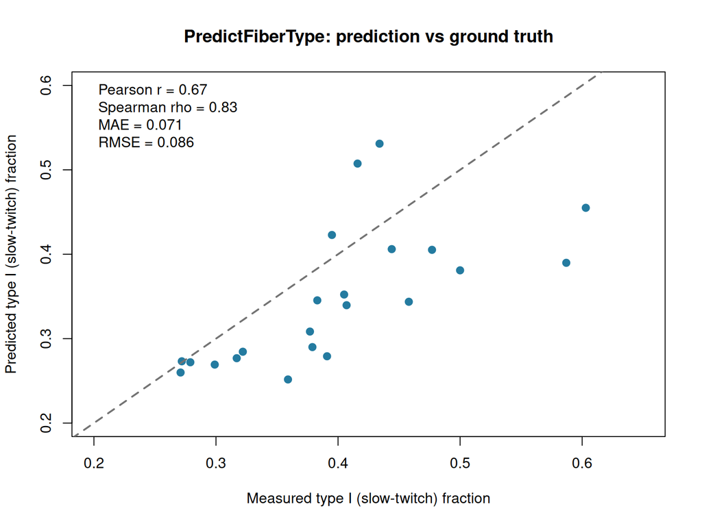

```r
# Convert percentages to proportions if the data are on a 0–100 scale.
comparison$predicted_prop <- if (max(comparison$predicted_type1, na.rm=TRUE) > 1.5)
  comparison$predicted_type1 / 100 else comparison$predicted_type1
comparison$true_prop <- if (max(comparison$true_type1, na.rm=TRUE) > 1.5)
  comparison$true_type1 / 100 else comparison$true_type1

pearson_r <- cor(comparison$true_prop, comparison$predicted_prop, method="pearson", use="complete.obs")
spearman_rho <- cor(comparison$true_prop, comparison$predicted_prop, method="spearman", use="complete.obs")
mae <- mean(abs(comparison$predicted_prop - comparison$true_prop))
rmse <- sqrt(mean((comparison$predicted_prop - comparison$true_prop)^2))

plot(comparison$true_prop, comparison$predicted_prop,
     xlim=c(0.2,0.65), ylim=c(0.2,0.6),
     xlab="Measured type I (slow-twitch) fraction",
     ylab="Predicted type I (slow-twitch) fraction",
     main="PredictFiberType: prediction vs ground truth",
     pch=19, col="#247BA0", cex=1.1)
abline(0,1,lty=2,lwd=2,col="grey45")
legend("topleft", bty="n", legend=c(
  sprintf("Pearson r = %.2f", pearson_r),
  sprintf("Spearman rho = %.2f", spearman_rho),
  sprintf("MAE = %.3f", mae),
  sprintf("RMSE = %.3f", rmse)))
```

```r
data.frame(n_matched_samples=nrow(comparison), pearson_r=pearson_r,
           spearman_rho=spearman_rho, MAE=mae, RMSE=rmse)
```

```
##   n_matched_samples pearson_r spearman_rho        MAE      RMSE
## 1                22 0.6686972     0.826087 0.07116282 0.0859738
```

# 7 Interpretation

- A positive correlation indicates that samples with higher measured type I fractions tend to receive higher predicted fractions.
- Correlation does not establish calibration: predictions can correlate with truth while systematically over- or under-estimating the fraction.
- If type I and type II are exhaustive classes, type II (fast-twitch) fraction is approximately `1 - predicted_type1`. Use this complement only when the two-class interpretation is appropriate.
- Accuracy depends on reference quality, similarity between reference and bulk samples, normalization, gene identifiers, and independent ground-truth measurements.

# 8 References

1. Gong T, Szustakowski JD. DeconRNASeq: a statistical framework for deconvolution of heterogeneous tissue samples based on mRNA-Seq data. *Bioinformatics*. 2013;29(8):1083–1085. https://doi.org/10.1093/bioinformatics/btt090
2. Oskolkov N, et al. High-throughput muscle fiber typing from RNA sequencing data. *Skeletal Muscle*. 2022. https://doi.org/10.1186/s13395-022-00299-4
3. PredictFiberType source code and example data: https://github.com/OlaHanssonLab/PredictFiberType